# MATH 3190 Homework 1

Focus: Notes 1-3

Due February 10, 2024

Now its time to practice what we have learned in class and learn even more! Note that your homework should be completed in R Markdown or Quarto (you can just add your answers to this document in the appropriate part) and Knitted to an html document or pdf document. You will `turn in’ this homework by uploading to your GitHub Math_3190_Assignment repository in the Homework/Homework_1 directory.

# Problem 1 (25 points)

### Part a (20 points)

Write two functions called `ghist` and `gbox` that are similar to my `ggraph` function that you put in your myplots.in package from Lab 2. Remember that the “in” should be replaced with your initials. The `ghist` function should create a ggplot histogram of a variable that is given as a vector. The `gbox` function should create a ggplot box plot when a single numeric vector is given or it should create side-by-side box plots if one numeric and one categorical variables are given. Allow the user to indicate whether it should be horizontal or vertical box plots. Be sure to properly document these functions.

### Part b (3 points)

Add those functions to your myplots.in package. Then run the `devtools::document()` function, update the DESCRIPTION file, and install your package to verify those functions work.

### Part c (2 points)

Update your GitHub myplots.in repo with the updated package. This is only worth 2 points, but I cannot verify you did part a without this, so it is actually worth much more.

# Problem 2 (60 points)

### Part a (9 points)

Learn about the `read.fwf()` function for use in downloading data from a URL into **R**. Learn about tools for downloading files from external servers. The `widths` and `strip.white` options will be especially useful here. Use this function to download the scores for all college basketball games for the 2023-2024 season (http://kenpom.com/cbbga24.txt) and then convert it to a tibble (load the `tidyverse` package first). The second team listed per line is the home team. It is not clear what the numbers, letters, or city names indicate after the second listed score. Notice that this is a “live” file that gets updated every day! So, your tibble size may change if you work on this assignment over the course of several days. That’s fine. Give the code you used to download these data.

```r
library(tidyverse)
library(dplyr)

data24 <- read.fwf( "http://kenpom.com/cbbga24.txt",
                     widths = c(10, 24, 3, 24, 3, 2, 20),
                     strip.white=TRUE) |>
  as_tibble()

head(data24)
```

| V1 | V2 | V3 | V4 | V5 | V6 | V7 |
| --- | --- | --- | --- | --- | --- | --- |
| 11/06/2023 | Portland St. | 62 | Air Force | 55 |  |  |
| 11/06/2023 | Morehead St. | 73 | Alabama | 105 |  |  |
| 11/06/2023 | Morgan St. | 59 | Arizona | 122 |  |  |
| 11/06/2023 | Alcorn St. | 59 | Arkansas | 93 |  |  |
| 11/06/2023 | Marist | 71 | Army | 55 |  |  |
| 11/06/2023 | Life | 72 | Austin Peay | 90 |  |  |

Now lets practice using our tidy data/tidyverse tools! Using your `cbbga24` tibble, try doing the following:

### Part b (2 points)

Use `rename()` to rename all of your variables to names that make sense.

```r
cbbga24 <-  data24 |> rename( 'Date' = V1,
  'Team_1' = V2,
  'Score_1' = V3,
  'Team_2' = V4,
  'Score_2' = V5,
  'Site_Type' = V6,
  'Game_Site' = V7
  )

head(cbbga24)
```

| Date | Team_1 | Score_1 | Team_2 | Score_2 | Site_Type | Game_Site |
| --- | --- | --- | --- | --- | --- | --- |
| 11/06/2023 | Portland St. | 62 | Air Force | 55 |  |  |
| 11/06/2023 | Morehead St. | 73 | Alabama | 105 |  |  |
| 11/06/2023 | Morgan St. | 59 | Arizona | 122 |  |  |
| 11/06/2023 | Alcorn St. | 59 | Arkansas | 93 |  |  |
| 11/06/2023 | Marist | 71 | Army | 55 |  |  |
| 11/06/2023 | Life | 72 | Austin Peay | 90 |  |  |

### Part c (2 points)

Use `mutate()` to create a new column that gives the score differences (team1$-$team2).

```r
cbbga24 <- cbbga24 |>
  mutate(Margin = Score_1-Score_2 )

head(cbbga24)
```

| Date | Team_1 | Score_1 | Team_2 | Score_2 | Site_Type | Game_Site | Margin |
| --- | --- | --- | --- | --- | --- | --- | --- |
| 11/06/2023 | Portland St. | 62 | Air Force | 55 |  |  | 7 |
| 11/06/2023 | Morehead St. | 73 | Alabama | 105 |  |  | -32 |
| 11/06/2023 | Morgan St. | 59 | Arizona | 122 |  |  | -63 |
| 11/06/2023 | Alcorn St. | 59 | Arkansas | 93 |  |  | -34 |
| 11/06/2023 | Marist | 71 | Army | 55 |  |  | 16 |
| 11/06/2023 | Life | 72 | Austin Peay | 90 |  |  | -18 |

### Part d (2 points)

Use `arrange()` to sort the data set by the home team.

```r
cbbga24 <- cbbga24 |> arrange(Team_1)

head(cbbga24)
```

| Date | Team_1 | Score_1 | Team_2 | Score_2 | Site_Type | Game_Site | Margin |
| --- | --- | --- | --- | --- | --- | --- | --- |
| 11/06/2023 | Abilene Christian | 64 | Oklahoma St. | 59 |  |  | 5 |
| 11/10/2023 | Abilene Christian | 64 | N.C. State | 84 |  |  | -20 |
| 11/17/2023 | Abilene Christian | 77 | San Jose St. | 71 | N | St. Thomas, VI | 6 |
| 11/20/2023 | Abilene Christian | 69 | Missouri St. | 87 | N | St. Thomas, VI | -18 |
| 11/29/2023 | Abilene Christian | 71 | UT Arlington | 86 |  |  | -15 |
| 12/21/2023 | Abilene Christian | 73 | Arkansas | 83 |  |  | -10 |

*Response*: The Home Team is typically listed first in column order for sports data sets. However when there is a ‘n’ neutral site type the teams would then be ordered alphabetically. Yet this does not seem to be the case for this data set.  
The `Site_Type` column is mostly empty with what appear to be irregular or unusually coded site types, e.g. ‘2N’. Some entries appear to have some correspondance with a game site state-wise, but are in fact coded with an ‘n’, e.g. the ‘away-team’ is Idaho St. and game site is Idaho Falls, ID, but is typed ‘n’. This data is treated simply by ordering the first column. The `Site_Type` data would need to be updated and reviewed for any use in ordering.

### Part e (2 points)

Use `select()` to remove the extra variable(s) that had that irrelevant information at the end of each line. Note: you can select every variable except one by using the “!”.

```r
cbbga24 <- cbbga24 |> select(!c(Site_Type, Game_Site))
head(cbbga24)
```

| Date | Team_1 | Score_1 | Team_2 | Score_2 | Margin |
| --- | --- | --- | --- | --- | --- |
| 11/06/2023 | Abilene Christian | 64 | Oklahoma St. | 59 | 5 |
| 11/10/2023 | Abilene Christian | 64 | N.C. State | 84 | -20 |
| 11/17/2023 | Abilene Christian | 77 | San Jose St. | 71 | 6 |
| 11/20/2023 | Abilene Christian | 69 | Missouri St. | 87 | -18 |
| 11/29/2023 | Abilene Christian | 71 | UT Arlington | 86 | -15 |
| 12/21/2023 | Abilene Christian | 73 | Arkansas | 83 | -10 |

### Part f (2 points)

Put parts a-e all together in one piping expression (with 5 pipes) and save this as a new object in **R**.

```r
cbbga24 <-  read.fwf( "http://kenpom.com/cbbga24.txt",
                     widths = c(10, 24, 3, 24, 3, 2, 20),
                     strip.white=TRUE) |>
  as_tibble() |>
  rename( 'Date' = V1,
  'Team_1' = V2,
  'Score_1' = V3,
  'Team_2' = V4,
  'Score_2' = V5,
  'Site_Type' = V6,
  'Game_Site' = V7) |>
  mutate(Margin = Score_1-Score_2 ) |>
  arrange(Team_1) |>
  select(!c(Site_Type, Game_Site))

head(cbbga24)
```

| Date | Team_1 | Score_1 | Team_2 | Score_2 | Margin |
| --- | --- | --- | --- | --- | --- |
| 11/06/2023 | Abilene Christian | 64 | Oklahoma St. | 59 | 5 |
| 11/10/2023 | Abilene Christian | 64 | N.C. State | 84 | -20 |
| 11/17/2023 | Abilene Christian | 77 | San Jose St. | 71 | 6 |
| 11/20/2023 | Abilene Christian | 69 | Missouri St. | 87 | -18 |
| 11/29/2023 | Abilene Christian | 71 | UT Arlington | 86 | -15 |
| 12/21/2023 | Abilene Christian | 73 | Arkansas | 83 | -10 |

### Part g (3 points)

Use `filter()` to reduce the data down to only games played in 2023 (you could use the `lubridate` package for this, since it specializes in dealing with dates, but some base **R** packages will also work). Save this in a new tibble. **We will use this tibble with only the 2023 years from here on out**.

```r
library(lubridate)
cbbga23 <- cbbga24 |>
  mutate(Date = mdy(Date)) |>
  #Run only once, a second run will not be able to parse the transformed dates again
  filter(between(Date, mdy("01/01/2023"), mdy("12/31/2023")))

head(cbbga23)
```

| Date | Team_1 | Score_1 | Team_2 | Score_2 | Margin |
| --- | --- | --- | --- | --- | --- |
| 2023-11-06 | Abilene Christian | 64 | Oklahoma St. | 59 | 5 |
| 2023-11-10 | Abilene Christian | 64 | N.C. State | 84 | -20 |
| 2023-11-17 | Abilene Christian | 77 | San Jose St. | 71 | 6 |
| 2023-11-20 | Abilene Christian | 69 | Missouri St. | 87 | -18 |
| 2023-11-29 | Abilene Christian | 71 | UT Arlington | 86 | -15 |
| 2023-12-21 | Abilene Christian | 73 | Arkansas | 83 | -10 |

### Part h (4 points)

Write a function that will filter the tibble to only games played by a given team. Demonstrate your function by displaying games played by SUU.

```r
byTeamGames <- function(data, team, ungroup){
  newTibble <- data |>
    rowwise() |>
    filter(any(c(Team_1, Team_2) == team)) |>
    ungroup() #if there is some other (non-lubridate parsed) formatting
  return(newTibble)
}

suu23 = byTeamGames(cbbga23, team = 'Southern Utah', ungroup=TRUE)

suu23
```

| Date | Team_1 | Score_1 | Team_2 | Score_2 | Margin |
| --- | --- | --- | --- | --- | --- |
| 2023-12-30 | Antelope Valley | 78 | Southern Utah | 95 | -17 |
| 2023-11-29 | Cal Baptist | 91 | Southern Utah | 66 | 25 |
| 2023-12-09 | Idaho St. | 74 | Southern Utah | 82 | -8 |
| 2023-11-09 | Life Pacific | 73 | Southern Utah | 108 | -35 |
| 2023-12-22 | Middle Tennessee | 63 | Southern Utah | 69 | -6 |
| 2023-11-06 | Southern Utah | 72 | Cal St. Bakersfield | 73 | -1 |
| 2023-11-14 | Southern Utah | 84 | Utah St. | 93 | -9 |
| 2023-11-21 | Southern Utah | 53 | Louisiana Tech | 67 | -14 |
| 2023-11-22 | Southern Utah | 74 | Texas St. | 67 | 7 |
| 2023-12-02 | Southern Utah | 63 | Seattle | 73 | -10 |

[output cut: 3 more lines]

### Part i (7 points)

Use `summarize()` to extract SUU’s win/loss record and winning percentage for their 2023 games. Hint: using the `case_when()` function inside of a `mutate()` function to create a new variable that indicates whether SUU won or lost is helpful.

```r
#adding new win/loss columns with strings and dummy-coding
suu23 <- suu23 |>
mutate(Result = case_when(
    Team_1 == 'Southern Utah' & Margin > 0 ~ 1,
    Team_1 == 'Southern Utah' & Margin < 0 ~ 0,
    Team_2 == 'Southern Utah' & Margin < 0 ~ 1,
    Team_2 == 'Southern Utah' & Margin > 0 ~ 0)) |>
  mutate(WinLoss = case_when(
    Result == 1 ~ 'Win',
    Result == 0 ~ 'Loss'))

#creating summary tibble
suu23perform <- suu23 |> filter(Team_1 == 'Southern Utah'| Team_2 == 'Southern Utah') |>
  summarize(
  Wins = sum(WinLoss == 'Win'),
  Losses = sum(WinLoss == 'Loss'),
  Percent_Win = round(Wins/(Wins+Losses)*100,2) |> paste0("%")
)

suu23perform
```

[output not shown]

### Part j (7 points)

Generalize this by writing a function that will do this for *a given* team.

Create a tibble with this information for *all* teams. (???)

Arrange this tibble by winning percentage (descending). The `add_row()` function may be useful here.

```r
team_Record <- function(data, team) {

 temp_Tibble <- data |>
  mutate(Result = case_when(
    Team_1 == team & Margin > 0 ~ 1,
    Team_1 == team & Margin < 0 ~ 0,
    Team_2 == team & Margin < 0 ~ 1,
    Team_2 == team & Margin > 0 ~ 0)) |>
  mutate(WinLoss = case_when(
    Result == 1 ~ 'Win',
    Result == 0 ~ 'Loss'))

   #creating summary tibble
result_Tibble <-  temp_Tibble |>
  filter(Team_1 == team | Team_2 == team) |>
  summarize(
    Team = team,
    Wins = sum(WinLoss == 'Win'),
    Losses = sum(WinLoss == 'Loss'),
    Percent_Win = round(Wins/(Wins+Losses)*100,2) %>% paste0("%"))

  return(result_Tibble)
}
```

```r
#Testing function team_Record with Oklahoma State
OKState_Rec = team_Record(cbbga23, 'Oklahoma St.')
OKState_Rec
```

| Team | Wins | Losses | Percent_Win |
| --- | --- | --- | --- |
| Oklahoma St. | 7 | 5 | 58.33% |

```r
#seems to work, especially if you don't try Abilene Christian, with the same record as SUU
```

```r
#and now for a totally different function that does something else to make that all team summary tibble

all_team_Record <- function(data) {


  unique_teams <- unique(c(data$Team_1, data$Team_2)) # vector of unique teams
  result_Tibble <- tibble() # tibble to store results

  for (team in unique_teams) {
    new_row <- team_Record(data, team)
    result_Tibble <- rbind(result_Tibble, new_row) #add_row() doesn't work here, IDKW
  }

  return(result_Tibble)
}

#now run nested-function function to obtain result record for all states in 2024

allTeamsResults <- all_team_Record(cbbga24) |>
  arrange(desc(Percent_Win))#for 2024

allTeamsResults
```

| Team | Wins | Losses | Percent_Win |
| --- | --- | --- | --- |
| Connecticut | 22 | 2 | 91.67% |
| Grand Canyon | 22 | 2 | 91.67% |
| Purdue | 22 | 2 | 91.67% |
| Coppin St. | 2 | 19 | 9.52% |
| Indiana St. | 22 | 3 | 88% |
| James Madison | 22 | 3 | 88% |
| Samford | 22 | 3 | 88% |
| Houston | 21 | 3 | 87.5% |
| McNeese St. | 21 | 3 | 87.5% |
| South Carolina | 21 | 3 | 87.5% |

[output cut: 709 more lines]

*Response:* Above is the tibble summarizing the results for the *2024* data. This would also work for the 2023 data, but this was not specified in the question. Unfortunately the `add_row()` function was not working for my particular code setup, although my reading of the description suggested it was more adapted to more uses of a tibble. The `rbind()` is used instead.

### Part k (8 points)

Write two functions that generate appropriate graphs for the basketball data. These two graphs could be anything you’d like and should use `ggplot2` and they should show something meaningful.

[figure not shown]

```r
cbbga24Month <- cbbga24 |>
  mutate(Date = mdy(Date)) |>
  mutate(Month = month(Date)) |>   #only run once, thank you...
  mutate(Month = factor(Month, levels = c(11, 12, 1, 2)))

cbbga24Month
```

| Date | Team_1 | Score_1 | Team_2 | Score_2 | Margin | Month |
| --- | --- | --- | --- | --- | --- | --- |
| 2023-11-06 | Abilene Christian | 64 | Oklahoma St. | 59 | 5 | 11 |
| 2023-11-10 | Abilene Christian | 64 | N.C. State | 84 | -20 | 11 |
| 2023-11-17 | Abilene Christian | 77 | San Jose St. | 71 | 6 | 11 |
| 2023-11-20 | Abilene Christian | 69 | Missouri St. | 87 | -18 | 11 |
| 2023-11-29 | Abilene Christian | 71 | UT Arlington | 86 | -15 | 11 |
| 2023-12-21 | Abilene Christian | 73 | Arkansas | 83 | -10 | 12 |
| 2023-12-30 | Abilene Christian | 84 | Western Kentucky | 86 | -2 | 12 |
| 2024-01-11 | Abilene Christian | 64 | Grand Canyon | 74 | -10 | 1 |
| 2024-01-13 | Abilene Christian | 53 | Cal Baptist | 68 | -15 | 1 |
| 2024-01-18 | Abilene Christian | 71 | Tarleton St. | 79 | -8 | 1 |

[output cut: 4597 more lines]

After preparing data for dates (only run once), the boxplot:

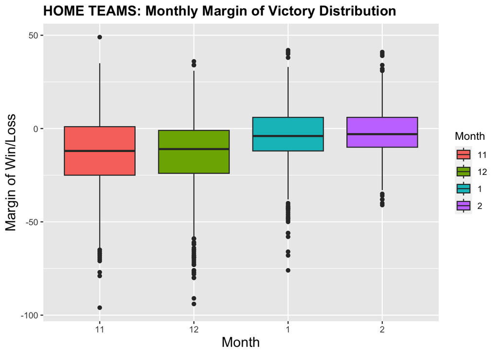

```r
#boxplot of monthly margin distributions
marginMonthly <- ggplot(cbbga24Month, aes(x = Month, y = Margin, fill = Month)) +
  geom_boxplot() +
  labs(title = "HOME TEAMS: Monthly Margin of Victory Distribution",
       x = "Month",
       y = "Margin of Win/Loss") +
  theme(axis.title=element_text(size = 14),
        plot.title =element_text(size = 14, face = "bold"))

marginMonthly
```

### Part l (12 points)

Create an **R** package that contains your functions from Parts h, j, and k and your tibble that contains all the games from 2023. You can use the the `write_csv()` function to save your tibble as a .csv file and put it in a `data-raw` folder in your package. Make sure the functions are properly documented. Upload this package to your GitHub page and indicate here what you called this package.

*Response:* This package is called `collegeBasketball.bs` in the form convention of this class. It should be found in my Math_3190_Assignments Git repository under Homework/Homework_1.